# Supplementary information 2: Statistics

Dusseldorp, G.L., Rutten, M., Pazan, K., Roussel, M., & Aleo, A.

2026-10-10

## Information

This is an R Markdown document containing the code and statistical procedures used in the paper “Relationship between TCSA of transversally hafted arrows and penetration effectiveness depends on the design of the entire projectile”, submitted to *Journal of Archaeological Science: Reports.* To run this file, which can be downloaded on [github](https://github.com/K-Pazan/TCSA), you will also need to download the data. It is available below in both rds and csv formats.

TCSA_data.rds

TCSA_data.csv

You will need to have the following packages downloaded in R: tidyverse (Wickham et al. 2019), car (Fox and Weisberg 2019), performance (Lüdecke et al. 2021), emmeans (Lenth and Piaskowski 2026), lme4 (Bates et al. 2015), lmerTest (Kuznetsova et al. 2017), glmmTMB (Brooks et al. 2017), and DHARMa (Hartig 2026). Any questions on the statistical methods in this paper can be directed to K.Pazan and G.L. Dusseldorp.

## 0. Data preparation

First, eliminate cases without measurements for penetration depth. This leaves 73 shots in the complete dataset.

```r
library(tidyverse)
TCSA_order <- TCSA_data %>%
  filter(Depth != "NA")
table(TCSA_order$Depth=="NA")
```

```
##
## FALSE
##    73
```

## 1. Linear mixed-effects model

### 1.1 Building the model

Because we wanted to test the significance of TCSA on penetration depth while controlling for differences between targets, we fitted a linear mixed effects model (LMM) using `Arrow` as a fixed effect and `Target` as a random effect (blocking factor), following the procedures in Mangiafico (2025) and using the REML criterion as recommended by Denis (2020). In this experimental design, `Target` is considered a random effect because the differences between targets 1-4 (which include immeasurable differences in density, temperature, etc.) cannot be precisely replicated in future experiments (Newman et al. 1997), and we are only interested in the differences between specific arrows, not specific targets. LMMs created using `lmer()` are relatively robust to unbalanced experimental designs like ours, which has different numbers of shots per target and arrow, and thus a better choice than a traditional linear model created using lm() or aov() (Mangiafico 2025). We tested the significance of our model’s terms using the `Anova()` function, which conducted Analysis of Deviance using a Type III Wald’s Chi-Square Test. In the model, the fixed effects (`Arrow`) were significant.

```r
library(car)
library(lme4)
library(lmerTest)
TCSA_order$Target <- as.factor(TCSA_order$Target)
TCSA_order$Arrow <- as.factor(TCSA_order$Arrow)
block_model <- lmer(Depth ~ Arrow + (1|Target), data=TCSA_order, REML = TRUE)
Anova(block_model, type = "III")
```

```
## Analysis of Deviance Table (Type III Wald chisquare tests)
##
## Response: Depth
##               Chisq Df Pr(>Chisq)
## (Intercept) 320.853  1  < 2.2e-16 ***
## Arrow        40.737  2  1.426e-09 ***
## ---
## Signif. codes:  0 '***' 0.001 '**' 0.01 '*' 0.05 '.' 0.1 ' ' 1
```

### 1.2 Tests of model assumptions

Before extracting pairwise comparisons and evaluating our model’s accuracy, we checked whether our model violated any assumptions. We conducted a Shapiro-Wilk test to check for normally distributed residuals and a Levene’s Test to check that residual variances did not differ significantly between arrow types. There was no evidence that the residual distribution diverged from normality (Shapiro-Wilk test, p = .140), but the assumption of homoscedasticity was violated (Levene’s test, p <.05), indicating differences in residual dispersion between arrow types.

```r
library(car)
TCSA_order$residuals <- residuals(block_model)
leveneTest(residuals ~ Arrow, data = TCSA_order)
```

```
## Levene's Test for Homogeneity of Variance (center = median)
##       Df F value  Pr(>F)
## group  2  3.4521 0.03717 *
##       70
## ---
## Signif. codes:  0 '***' 0.001 '**' 0.01 '*' 0.05 '.' 0.1 ' ' 1
```

```r
shapiro.test(residuals(block_model))
```

```
##
##  Shapiro-Wilk normality test
##
## data:  residuals(block_model)
## W = 0.9742, p-value = 0.1395
```

We also visualized diagnostic plots using `check_model()` in the package *performance* (Lüdecke et al. 2021). The plots also indicated issues with model fit, especially a departure from homogeneity of variance and the effects of several influential observations.

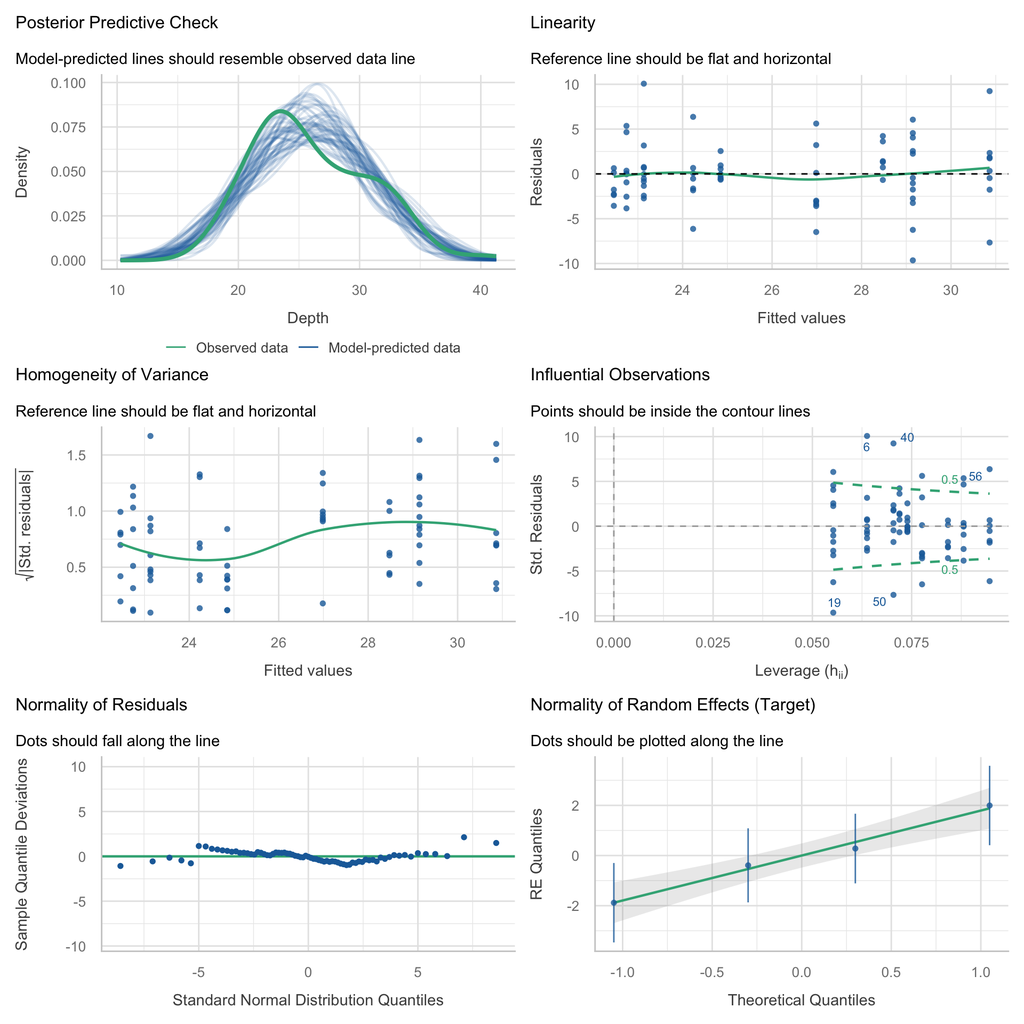

### 1.3 Accounting for residual dispersion

We fitted another model using the glmmTMB() function in the package *glmmTMB* (Brooks et al. 2017), which includes an argument `dispformula` that can model differences in residual dispersion between treatment groups (in this case, arrow types). We tested the significance of the fixed effects, and found that arrow type was significant.

```r
library(glmmTMB)
library(DHARMa)
arrow_model <- glmmTMB(Depth ~ Arrow + (1|Target), dispformula = ~ Arrow, data = TCSA_order)
Anova(arrow_model, type ="III")
```

```
## Analysis of Deviance Table (Type III Wald chisquare tests)
##
## Response: Depth
##              Chisq Df Pr(>Chisq)
## (Intercept) 370.45  1  < 2.2e-16 ***
## Arrow        40.70  2  1.452e-09 ***
## ---
## Signif. codes:  0 '***' 0.001 '**' 0.01 '*' 0.05 '.' 0.1 ' ' 1
```

### 1.4 Re-evaluating the improved model

We used the procedures recommended for glmmTMB() objects in the *DHARMa* package manual (Hartig 2026) to assess our model, `arrow_model`. The QQ plot shows normally distributed residuals, an observation supported by a Kolmogorov-Smirnov Test (p = .711). The Levene’s Test on group variances was also insignificant.

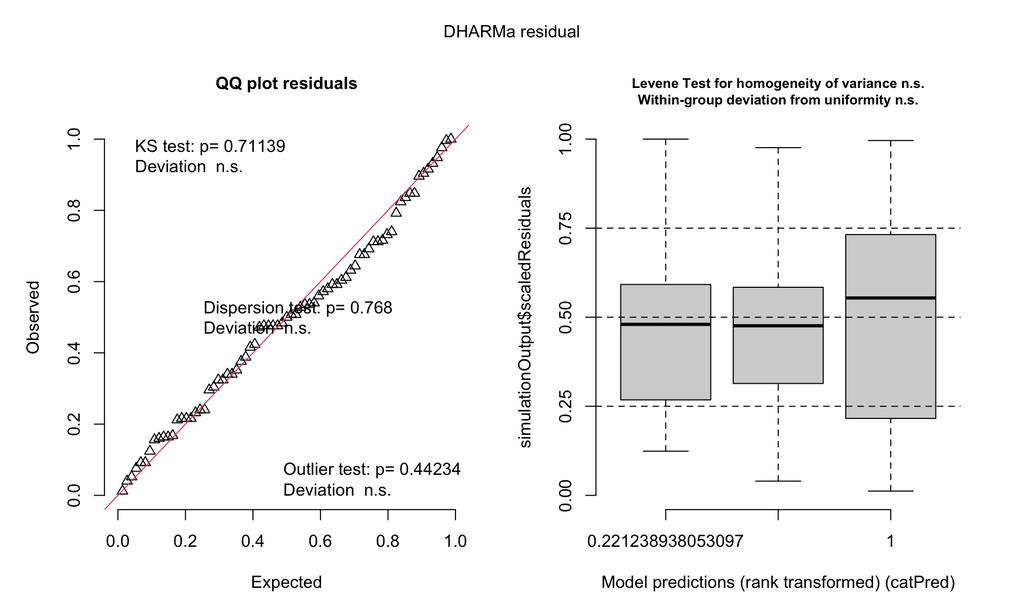

```r
library(DHARMa)
sim_residuals <- simulateResiduals(fittedModel = arrow_model, plot = TRUE)
```

The diagnostic plots produced by *performance* (Lüdecke et al. 2021) also indicated that our new `arrow_model` had resolved the issues of the first model (`block_model`). Homogeniety of variance and the posterior predictive check are significantly improved, the random effects of target are normally distributed, and there is a linear relationship between the independent variables and outcome (depth).

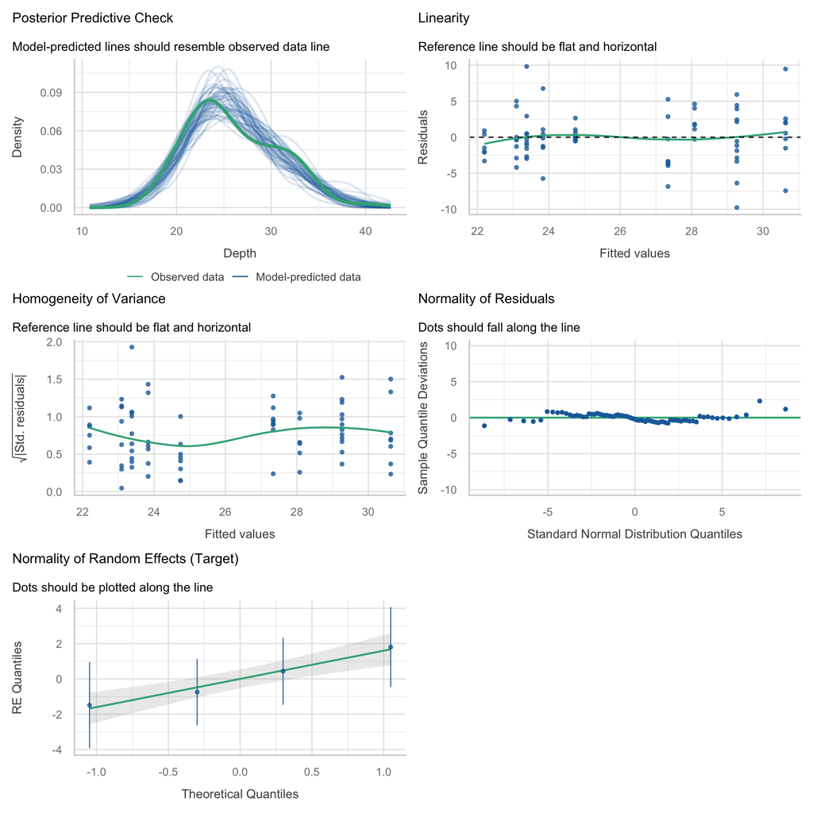

```r
check_model(arrow_model)
```

### 1.5 Improvement over null model

We built a null model, consisting of only an intercept and the random effect of `Target`, against which to evaluate the fit of our model. We also conducted a simulated Likelihood Ratio Test comparing the null model to `arrow_model`. Both the AIC (432.2 for the null model vs. 407.06 for the arrow model) and the simulated LRT (p < .001) indicate that the model including arrow as a fixed effect is a better fit than the null model that does not include arrow type.

```r
null_arrow <-  glmmTMB(Depth ~ 1 + (1|Target), dispformula = ~ Arrow, data = TCSA_order)
anova(arrow_model, null_arrow, test="Chisq")
```

```
## Data: TCSA_order
## Models:
## null_arrow: Depth ~ 1 + (1 | Target), zi=~0, disp=~Arrow
## arrow_model: Depth ~ Arrow + (1 | Target), zi=~0, disp=~Arrow
##             Df    AIC    BIC  logLik deviance  Chisq Chi Df Pr(>Chisq)
## null_arrow   5 432.20 443.65 -211.10   422.20
## arrow_model  7 407.06 423.10 -196.53   393.06 29.137      2   4.71e-07 ***
## ---
## Signif. codes:  0 '***' 0.001 '**' 0.01 '*' 0.05 '.' 0.1 ' ' 1
```

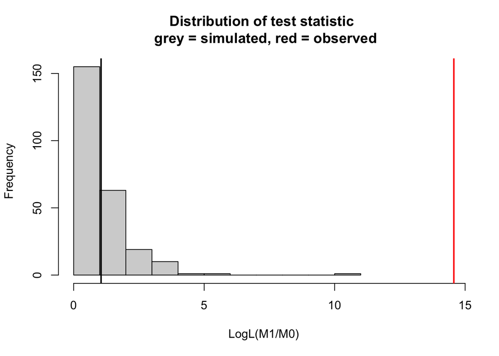

```
##
##  DHARMa simulated LRT
##
## data:  m0: null_arrow m1: arrow_model
## LogL(M1/M0) = 14.568, p-value < 2.2e-16
## alternative hypothesis: M1 describes the data better than M0
```

```r
simulateLRT(null_arrow, arrow_model)
```

### 1.6 Pairwise comparisons

Having established that our model including arrow type provided a better fit than the null model, we then completed pairwise comparisons between the different arrow types using the estimated marginal means (EMM) for each arrow type, or mean penetration depths corrected for the model specifications - in this case, the random effect of target, and differences in residual variance (Lenth and Piaskowski 2026). P-values were adjusted using Tukey’s method. We also calculated confidence intervals for differences in EMMs. The medium arrow had the greatest EMM of 28.8 cm. The differences in mean penetration depth are significant when comparing the medium vs. small arrow (p <.001) and the medium vs. large arrow (p = .004). The difference in mean penetration depth of the large vs. small arrow is not statistically significant.

```r
library(emmeans)
emmeans_arrow <- emmeans(arrow_model, pairwise ~ Arrow)
emmeans_arrow
```

```
## $emmeans
##  Arrow  emmean    SE  df asymp.LCL asymp.UCL
##  Large    24.6 1.280 Inf      22.1      27.1
##  Medium   28.8 1.020 Inf      26.8      30.8
##  Small    22.9 0.972 Inf      21.0      24.8
##
## Confidence level used: 0.95
##
## $contrasts
##  contrast       estimate    SE  df z.ratio p.value
##  Large - Medium    -4.24 1.320 Inf  -3.212  0.0038
##  Large - Small      1.64 1.420 Inf   1.153  0.4813
##  Medium - Small     5.89 0.958 Inf   6.144 <0.0001
##
## P value adjustment: tukey method for comparing a family of 3 estimates
```

```r
confint(pairs(emmeans_arrow))
```

```
##  contrast       estimate    SE  df asymp.LCL asymp.UCL
##  Large - Medium    -4.24 1.320 Inf     -7.34     -1.15
##  Large - Small      1.64 1.420 Inf     -1.69      4.98
##  Medium - Small     5.89 0.958 Inf      3.64      8.13
##
## Confidence level used: 0.95
## Conf-level adjustment: tukey method for comparing a family of 3 estimates
```

## 2. Accounting for the effects of shot order

For additional confirmation of our results, we fitted another LMM using `Target` as a random effect and shot order (scaled by target to account for differences in the number of shots) and `Arrow` as variables with fixed effects. Like our `arrow_model`, this tests for differences between means in penetration depth while blocking the effects of `Target`, but also allows to evaluate whether shot order had an independent effect on penetration. We fitted the model using the complete dataset (n = 73). `Shot_order` was not a significant term in the model, and when we compared this model against the `arrow_model`, there was insufficient evidence to conclude that keeping `Shot_order` improved fit. Both the ANOVA and the simulated LRT comparing the two models were insignificant.

```r
TCSA_order <- TCSA_order %>%
group_by(Target) %>%
mutate(Shot_order= as.numeric(scale(Shot))) %>%
ungroup()
shot_model <- glmmTMB(Depth ~ Arrow + Shot_order + (1|Target), dispformula = ~ Arrow, data = TCSA_order)
Anova(shot_model, type = "III")
```

```
## Analysis of Deviance Table (Type III Wald chisquare tests)
##
## Response: Depth
##                Chisq Df Pr(>Chisq)
## (Intercept) 357.2501  1  < 2.2e-16 ***
## Arrow        34.1835  2  3.777e-08 ***
## Shot_order    0.4656  1      0.495
## ---
## Signif. codes:  0 '***' 0.001 '**' 0.01 '*' 0.05 '.' 0.1 ' ' 1
```

```r
anova(arrow_model, shot_model)
```

```
## Data: TCSA_order
## Models:
## arrow_model: Depth ~ Arrow + (1 | Target), zi=~0, disp=~Arrow
## shot_model: Depth ~ Arrow + Shot_order + (1 | Target), zi=~0, disp=~Arrow
##             Df    AIC    BIC  logLik deviance  Chisq Chi Df Pr(>Chisq)
## arrow_model  7 407.06 423.10 -196.53   393.06
## shot_model   8 408.60 426.92 -196.30   392.60 0.4626      1     0.4964
```

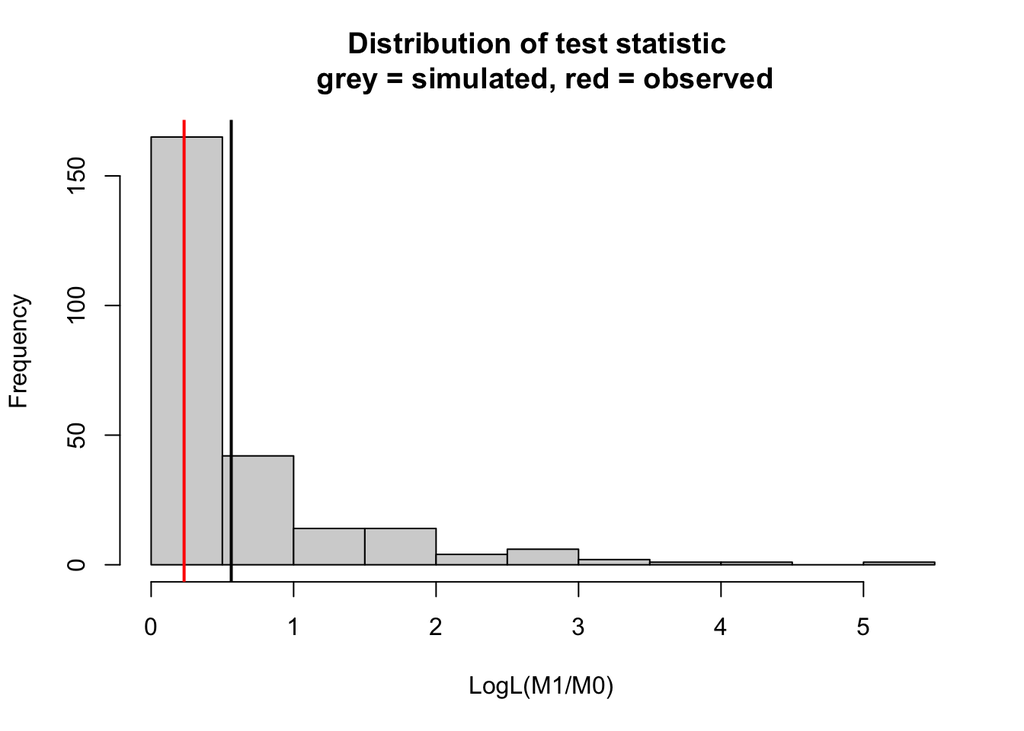

```
##
##  DHARMa simulated LRT
##
## data:  m0: arrow_model m1: shot_model
## LogL(M1/M0) = 0.2313, p-value = 0.54
## alternative hypothesis: M1 describes the data better than M0
```

```r
simulateLRT(arrow_model,shot_model)
```

## 3. Robust model

### 3.1 Elimination of problematic shots

To evaluate the robusticity of our conclusions, we eliminated shots that were deemed potentially problematic. These either shared entry wounds with other shots, or entered very close to other entry wounds. This decreased the total sample size from 73 to 66 shots.

```r
TCSA_clean <- TCSA_order %>%
  filter(Problem=="FALSE")
summary(TCSA_clean)
```

```
##  Target    Arrow        Depth            Shot            Comments
##  1:17   Large :14   Min.   :18.10   Min.   : 1.00   Length   :66
##  2:15   Medium:30   1st Qu.:22.73   1st Qu.: 6.00   N.unique : 4
##  3:16   Small :22   Median :24.40   Median :10.50   N.blank  : 0
##  4:18               Mean   :25.89   Mean   :11.09   Min.nchar:24
##                     3rd Qu.:29.18   3rd Qu.:16.00   Max.nchar:52
##                     Max.   :40.10   Max.   :25.00   NAs      :62
##   Problem          residuals          Shot_order
##  Mode :logical   Min.   :-7.66283   Min.   :-1.686850
##  FALSE:66        1st Qu.:-1.81662   1st Qu.:-0.775359
##                  Median :-0.04952   Median :-0.031777
##                  Mean   :-0.09659   Mean   : 0.007829
##                  3rd Qu.: 1.39919   3rd Qu.: 0.804482
##                  Max.   : 9.23717   Max.   : 1.811504
```

### 3.2 LMM using robust data

We fitted an LMM using this smaller dataset. Arrow remains significant in the model.

```r
robust_model <- glmmTMB(Depth ~ Arrow + (1|Target), dispformula = ~ Arrow, data = TCSA_clean)
Anova(robust_model, type = "III")
```

```
## Analysis of Deviance Table (Type III Wald chisquare tests)
##
## Response: Depth
##               Chisq Df Pr(>Chisq)
## (Intercept) 402.472  1  < 2.2e-16 ***
## Arrow        62.541  2  2.627e-14 ***
## ---
## Signif. codes:  0 '***' 0.001 '**' 0.01 '*' 0.05 '.' 0.1 ' ' 1
```

### 3.3 Evaluation of robust model

We evaluated the robust model using the same procedures. The robust model fulfilled all LMM assumptions, including homogeneity and normality of residual variance, and was also an improvement over a null model as indicated by a simulated LRT (p < .001) and a lower AIC value (340.86 vs. 372.45).

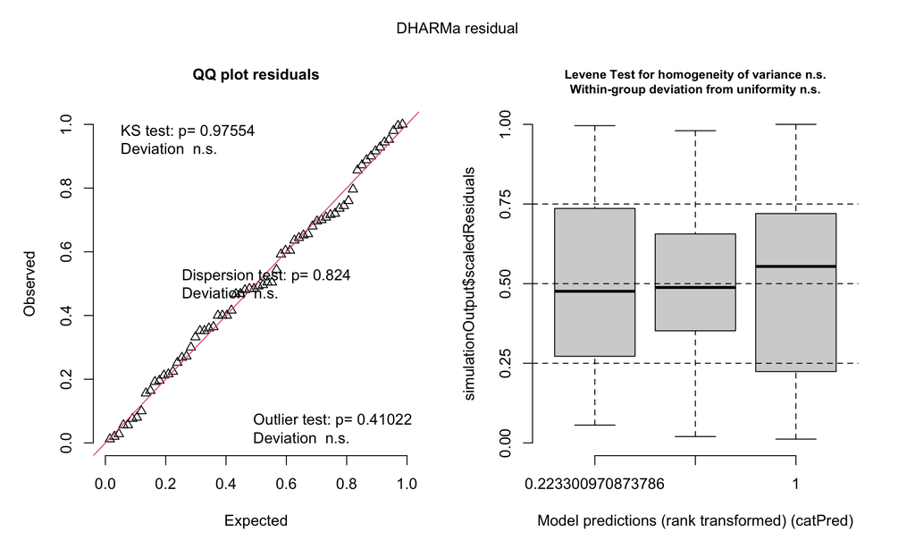

```r
library(DHARMa)
robust_residuals <- simulateResiduals(fittedModel = robust_model, plot = TRUE)
```

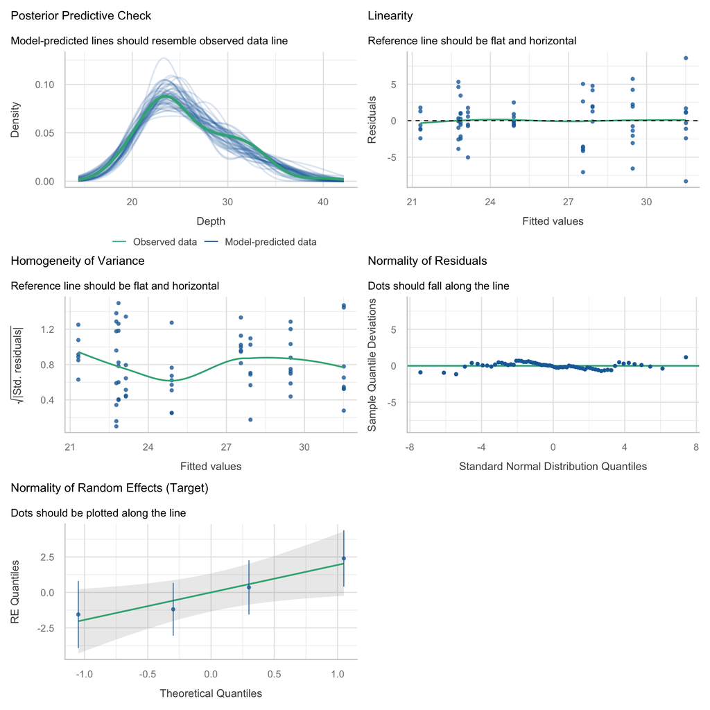

```r
check_model(robust_model)
```

```r
null_robust <-  glmmTMB(Depth ~ 1 + (1|Target), dispformula = ~ Arrow, data = TCSA_clean)
anova(robust_model, null_robust)
```

```
## Data: TCSA_clean
## Models:
## null_robust: Depth ~ 1 + (1 | Target), zi=~0, disp=~Arrow
## robust_model: Depth ~ Arrow + (1 | Target), zi=~0, disp=~Arrow
##              Df    AIC    BIC  logLik deviance  Chisq Chi Df Pr(>Chisq)
## null_robust   5 372.45 383.40 -181.22   362.45
## robust_model  7 340.86 356.19 -163.43   326.86 35.588      2  1.871e-08 ***
## ---
## Signif. codes:  0 '***' 0.001 '**' 0.01 '*' 0.05 '.' 0.1 ' ' 1
```

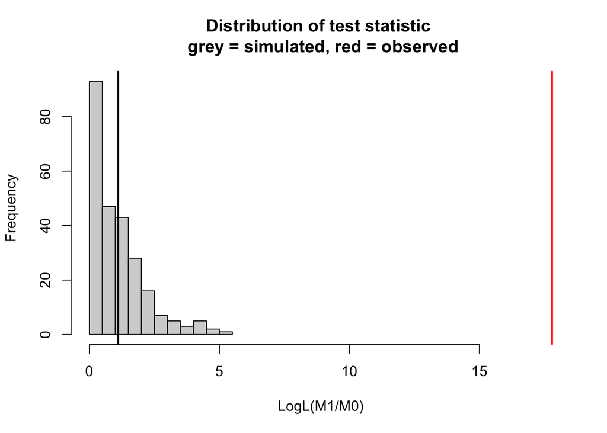

```
##
##  DHARMa simulated LRT
##
## data:  m0: null_robust m1: robust_model
## LogL(M1/M0) = 17.794, p-value < 2.2e-16
## alternative hypothesis: M1 describes the data better than M0
```

```r
simulateLRT(null_robust, robust_model)
```

### 3.4 Pairwise comparisons for robust model

When we performed pairwise comparisons on the robust model, we obtained nearly identical results to our model on the full dataset. The medium arrow (emmean = 29.1 cm) penetrated more deeply than the large (p <.001) and small (p < .001) arrows.

```r
emmeans(robust_model, pairwise ~ Arrow)
```

```
## $emmeans
##  Arrow  emmean    SE  df asymp.LCL asymp.UCL
##  Large    24.3 1.210 Inf      22.0      26.7
##  Medium   29.1 1.100 Inf      27.0      31.3
##  Small    22.5 0.943 Inf      20.7      24.4
##
## Confidence level used: 0.95
##
## $contrasts
##  contrast       estimate    SE  df z.ratio p.value
##  Large - Medium    -4.78 1.160 Inf  -4.112  0.0001
##  Large - Small      1.83 1.130 Inf   1.620  0.2371
##  Medium - Small     6.61 0.843 Inf   7.842 <0.0001
##
## P value adjustment: tukey method for comparing a family of 3 estimates
```

Bates, Douglas, Martin Mächler, Ben Bolker, and Steve Walker. 2015. *Fitting Linear Mixed-Effects Models Using lme4*. 67 (1): 1–48. https://doi.org/10.18637/jss.v067.i01.

Brooks, Mollie E., Kasper Kristensen, Koen J. van, et al. 2017. *glmmTMB Balances Speed and Flexibility Among Packages for Zero-Inflated Generalized Linear Mixed Modeling*. 9. https://doi.org/10.32614/RJ-2017-066.

Denis, Daniel J. 2020. *Univariate, Bivariate, and Multivariate Statistics Using r: Quantitative Tools for Data Analysis and Data Science*. Wiley. https://csu-stan.primo.exlibrisgroup.com/discovery/fulldisplay?docid=alma991071900432302901&context=L&vid=01CALS_UST:01CALS_UST&lang=en&search_scope=MyInst_and_CI&adaptor=Local%20Search%20Engine.

Fox, John, and Sanford Weisberg. 2019. *An r Companion to Applied Regression*. https://www.john-fox.ca/Companion/.

Hartig, Florian. 2026. *DHARMa: Residual Diagnostics for Hierarchical (Multi-Level / Mixed) Regression Models*. https://doi.org/10.32614/CRAN.package.DHARMa.

Kuznetsova, Alexandra, Per B. Brockhoff, and Rune H. B. Christensen. 2017. *lmerTest Package: Tests in Linear Mixed Effects Models*. 82. https://doi.org/10.18637/jss.v082.i13.

Lenth, Russell V., and Julia Piaskowski. 2026. *Emmeans: Estimated Marginal Means, Aka Least-Squares Means*. https://doi.org/10.32614/CRAN.package.emmeans.

Lüdecke, Daniel, Mattan S. Ben-Shachar, Indrajeet Patil, Philip Waggoner, and Dominique Makowski. 2021. *Performance: An r Package for Assessment, Comparison and Testing of Statistical Models*. 6: 3139. https://doi.org/10.21105/joss.03139.

Mangiafico, Salvatore. 2025. *An r Companion for the Handbook of Biological Statistics*. Version 1.4.2. https://rcompanion.org/rcompanion/.

Newman, Jonathan A., Joy Bergelson, and Alan Grafen. 1997. “Blocking Factors and Hypothesis Tests in Ecology: Is Your Statistics Text Wrong?” *Ecology* 78 (5): 1312–20. https://doi.org/10.1890/0012-9658(1997)078[1312:BFAHTI]2.0.CO;2.

Wickham, Hadley, Mara Averick, Jennifer Bryan, et al. 2019. *Welcome to the Tidyverse*. 4: 1686. https://doi.org/10.21105/joss.01686.